# DTSC 710 Homework 3: Building Linear Regression Model

Selina Narain

ID 1261565

Building Linear Regression Model by Hand Picking Features

```python
# Importing necessary libraries
import pandas as pd
import math
import numpy as np
import matplotlib.pyplot as plt
import seaborn as sns
from sklearn.model_selection import train_test_split, cross_val_score, KFold, GridSearchCV
from sklearn.linear_model import LinearRegression
from sklearn.feature_selection import RFE
from sklearn.metrics import mean_squared_error
from sklearn.preprocessing import StandardScaler
from sklearn.decomposition import PCA
```

```python
# Reading Boston Housing csv file and initializing into dataframe
df1 = pd.read_csv('/Users/selinanarain/Desktop/DTSC710/HW3/BostonHousing.csv')
df1
```

|  | crim | zn | indus | chas | nox | rm | age | dis | rad | tax | ptratio | b | lstat | medv |
| --- | --- | --- | --- | --- | --- | --- | --- | --- | --- | --- | --- | --- | --- | --- |
| 0 | 0.00632 | 18.0 | 2.31 | 0 | 0.538 | 6.575 | 65.2 | 4.0900 | 1 | 296 | 15.3 | 396.90 | 4.98 | 24.0 |
| 1 | 0.02731 | 0.0 | 7.07 | 0 | 0.469 | 6.421 | 78.9 | 4.9671 | 2 | 242 | 17.8 | 396.90 | 9.14 | 21.6 |
| 2 | 0.02729 | 0.0 | 7.07 | 0 | 0.469 | 7.185 | 61.1 | 4.9671 | 2 | 242 | 17.8 | 392.83 | 4.03 | 34.7 |
| 3 | 0.03237 | 0.0 | 2.18 | 0 | 0.458 | 6.998 | 45.8 | 6.0622 | 3 | 222 | 18.7 | 394.63 | 2.94 | 33.4 |
| 4 | 0.06905 | 0.0 | 2.18 | 0 | 0.458 | 7.147 | 54.2 | 6.0622 | 3 | 222 | 18.7 | 396.90 | 5.33 | 36.2 |
| ... | ... | ... | ... | ... | ... | ... | ... | ... | ... | ... | ... | ... | ... | ... |
| 501 | 0.06263 | 0.0 | 11.93 | 0 | 0.573 | 6.593 | 69.1 | 2.4786 | 1 | 273 | 21.0 | 391.99 | 9.67 | 22.4 |
| 502 | 0.04527 | 0.0 | 11.93 | 0 | 0.573 | 6.120 | 76.7 | 2.2875 | 1 | 273 | 21.0 | 396.90 | 9.08 | 20.6 |
| 503 | 0.06076 | 0.0 | 11.93 | 0 | 0.573 | 6.976 | 91.0 | 2.1675 | 1 | 273 | 21.0 | 396.90 | 5.64 | 23.9 |
| 504 | 0.10959 | 0.0 | 11.93 | 0 | 0.573 | 6.794 | 89.3 | 2.3889 | 1 | 273 | 21.0 | 393.45 | 6.48 | 22.0 |
| 505 | 0.04741 | 0.0 | 11.93 | 0 | 0.573 | 6.030 | 80.8 | 2.5050 | 1 | 273 | 21.0 | 396.90 | 7.88 | 11.9 |

506 rows × 14 columns

```python
df1.head()
```

|  | crim | zn | indus | chas | nox | rm | age | dis | rad | tax | ptratio | b | lstat | medv |
| --- | --- | --- | --- | --- | --- | --- | --- | --- | --- | --- | --- | --- | --- | --- |
| 0 | 0.00632 | 18.0 | 2.31 | 0 | 0.538 | 6.575 | 65.2 | 4.0900 | 1 | 296 | 15.3 | 396.90 | 4.98 | 24.0 |
| 1 | 0.02731 | 0.0 | 7.07 | 0 | 0.469 | 6.421 | 78.9 | 4.9671 | 2 | 242 | 17.8 | 396.90 | 9.14 | 21.6 |
| 2 | 0.02729 | 0.0 | 7.07 | 0 | 0.469 | 7.185 | 61.1 | 4.9671 | 2 | 242 | 17.8 | 392.83 | 4.03 | 34.7 |
| 3 | 0.03237 | 0.0 | 2.18 | 0 | 0.458 | 6.998 | 45.8 | 6.0622 | 3 | 222 | 18.7 | 394.63 | 2.94 | 33.4 |
| 4 | 0.06905 | 0.0 | 2.18 | 0 | 0.458 | 7.147 | 54.2 | 6.0622 | 3 | 222 | 18.7 | 396.90 | 5.33 | 36.2 |

## Part 1 - Preprocessing: 20%

● Find missing value. Fill missing values by the mean of the corresponding column

```python
df1.isnull().sum()

# Calculates count of missing values per column. No missing values detected.
```

```
crim       0
zn         0
indus      0
chas       0
nox        0
rm         0
age        0
dis        0
rad        0
tax        0
ptratio    0
b          0
lstat      0
medv       0
dtype: int64
```

● Use heatmap to identify Multicollinearity.

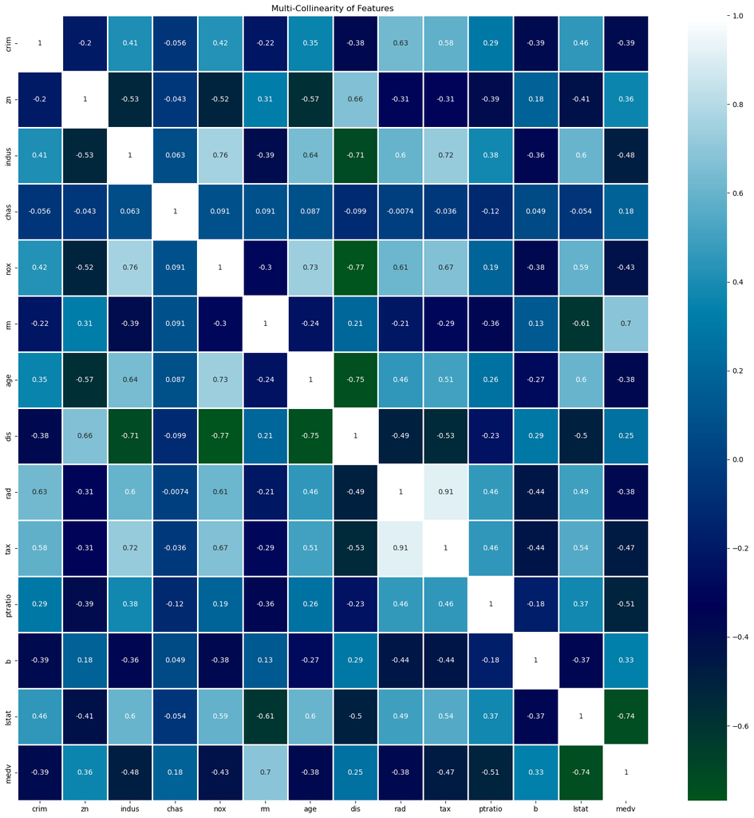

```python
# Create a covariance matrix
corr = df1.corr()

# Set up the matplotlib figure
f, ax = plt.subplots(figsize=(20,20))

# Draw the heatmap
sns.heatmap(corr, center=0, linewidths=0.8, cmap='ocean', annot=True)
ax.set_title('Multi-Collinearity of Features')
plt.savefig('multiCollinearityFigure.png')
```

● If two independent variables are correlated with each other, you may remove the one that is less correlated with the dependent variable.

```python
# Define correlation with target variable (medv)
cor_target = abs(corr["medv"])

# Select highly correlated features - covariance greater than 0.5
relevant_features = cor_target[cor_target > 0.5]
relevant_features
```

```
rm         0.695360
ptratio    0.507787
lstat      0.737663
medv       1.000000
Name: medv, dtype: float64
```

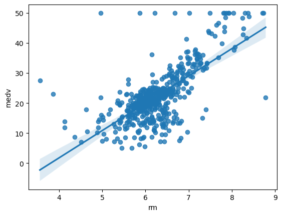

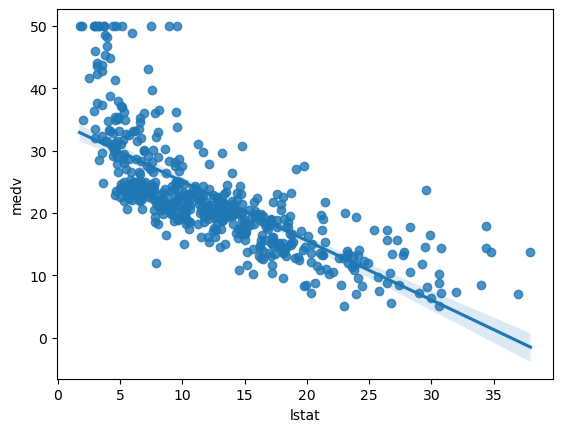

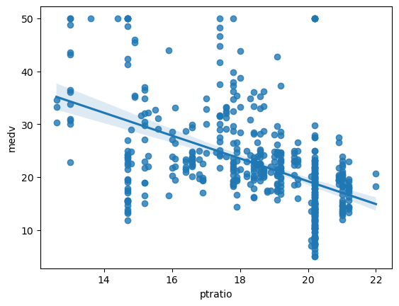

```python
# Plot the relationship highly correlated features

for var in ['rm', 'lstat', 'ptratio']:
    sns.regplot(x=df1[var], y=df1['medv'], data = df1)
    plt.show()
```

```python
# Create covariance matrix between highly correlated independent variables
print(df1[["ptratio", "lstat"]].corr())
print(df1[["rm", "lstat"]].corr())
```

```
          ptratio     lstat
ptratio  1.000000  0.374044
lstat    0.374044  1.000000
             rm     lstat
rm     1.000000 -0.613808
lstat -0.613808  1.000000
```

```python
# rm highly correlated with lstat
# rm less correlated with mdev than lstat

#Drop least correlated variable (rm)
df1 = df1.drop(columns = ['rm'], axis = 1)
```

● Drop columns that have no correlation with the dependent variable.

```python
# Identify features with corelation less than 0.5
nonrelevant_features = cor_target[cor_target < 0.5]
nonrelevant_features
```

```
crim     0.388305
zn       0.360445
indus    0.483725
chas     0.175260
nox      0.427321
age      0.376955
dis      0.249929
rad      0.381626
tax      0.468536
b        0.333461
Name: medv, dtype: float64
```

```python
# Drop features with corelation less than 0.5
df1 = df1.drop(columns=['crim', 'zn', 'indus', 'chas', 'nox', 'age', 'dis', 'rad', 'tax', 'b'], axis = 1)
df1
```

|  | ptratio | lstat | medv |
| --- | --- | --- | --- |
| 0 | 15.3 | 4.98 | 24.0 |
| 1 | 17.8 | 9.14 | 21.6 |
| 2 | 17.8 | 4.03 | 34.7 |
| 3 | 18.7 | 2.94 | 33.4 |
| 4 | 18.7 | 5.33 | 36.2 |
| ... | ... | ... | ... |
| 501 | 21.0 | 9.67 | 22.4 |
| 502 | 21.0 | 9.08 | 20.6 |
| 503 | 21.0 | 5.64 | 23.9 |
| 504 | 21.0 | 6.48 | 22.0 |
| 505 | 21.0 | 7.88 | 11.9 |

506 rows × 3 columns

## Part 2 - Build model to get baseline - 20%

● Perform 8:2 test/train split

```python
# Split dataset into highly correlated features and target variable
feature_names = ['ptratio', 'lstat']
X = df1[feature_names] # Features
y = df1.medv # Target variable
```

```python
# Split df into train and test sets 80% training and 20% test
X_train, X_test, y_train, y_test = train_test_split(X, y, test_size = 0.2, random_state = 42)
```

● Train model with all remaining variables.

```python
# Create linear regression object
linearRegModel1 = LinearRegression()

# Train linear regression model 1
linearRegModel1 = linearRegModel1.fit(X_train,y_train)

# Predict the response for test dataset
y_pred = linearRegModel1.predict(X_test)
```

● Perform 10 Fold Cross Validation.

```python
# Establish 10 fold cross-validation
cv = KFold(n_splits = 10, shuffle = True, random_state = 42)

# Obtain cross validation score w/ neg_root_mean_squared_error
scores = cross_val_score(linearRegModel1, X_train, y_train, scoring='neg_root_mean_squared_error', cv = cv)
scores
```

```
array([-3.93252472, -6.07862169, -6.35411259, -6.26685638, -7.79795756,
       -6.70513412, -4.71665087, -7.28118656, -4.56356008, -4.55564488])
```

● Report mean of RMSE

```python
# Calculate mean of RMSE for handpicked features model
rmseMean1 = np.mean(np.absolute(scores))
rmseMean1
```

```
5.825224945569638
```

● Report SD of RMSE

```python
# Calculate standard deviation of RMSE for handpicked features model
rmseStd1 = np.std(np.absolute(scores))
rmseStd1
```

```
1.2385310312184938
```

Build Linear Regression Model Using PCA Selected Features

## Part 3 - Create Principle Components - 20%

● Load dataset into new dataframe

```python
# Reading Boston Housing csv file and initializing into dataframe
df2 = pd.read_csv('/Users/selinanarain/Desktop/DTSC710/HW3/BostonHousing.csv')
df2
```

|  | crim | zn | indus | chas | nox | rm | age | dis | rad | tax | ptratio | b | lstat | medv |
| --- | --- | --- | --- | --- | --- | --- | --- | --- | --- | --- | --- | --- | --- | --- |
| 0 | 0.00632 | 18.0 | 2.31 | 0 | 0.538 | 6.575 | 65.2 | 4.0900 | 1 | 296 | 15.3 | 396.90 | 4.98 | 24.0 |
| 1 | 0.02731 | 0.0 | 7.07 | 0 | 0.469 | 6.421 | 78.9 | 4.9671 | 2 | 242 | 17.8 | 396.90 | 9.14 | 21.6 |
| 2 | 0.02729 | 0.0 | 7.07 | 0 | 0.469 | 7.185 | 61.1 | 4.9671 | 2 | 242 | 17.8 | 392.83 | 4.03 | 34.7 |
| 3 | 0.03237 | 0.0 | 2.18 | 0 | 0.458 | 6.998 | 45.8 | 6.0622 | 3 | 222 | 18.7 | 394.63 | 2.94 | 33.4 |
| 4 | 0.06905 | 0.0 | 2.18 | 0 | 0.458 | 7.147 | 54.2 | 6.0622 | 3 | 222 | 18.7 | 396.90 | 5.33 | 36.2 |
| ... | ... | ... | ... | ... | ... | ... | ... | ... | ... | ... | ... | ... | ... | ... |
| 501 | 0.06263 | 0.0 | 11.93 | 0 | 0.573 | 6.593 | 69.1 | 2.4786 | 1 | 273 | 21.0 | 391.99 | 9.67 | 22.4 |
| 502 | 0.04527 | 0.0 | 11.93 | 0 | 0.573 | 6.120 | 76.7 | 2.2875 | 1 | 273 | 21.0 | 396.90 | 9.08 | 20.6 |
| 503 | 0.06076 | 0.0 | 11.93 | 0 | 0.573 | 6.976 | 91.0 | 2.1675 | 1 | 273 | 21.0 | 396.90 | 5.64 | 23.9 |
| 504 | 0.10959 | 0.0 | 11.93 | 0 | 0.573 | 6.794 | 89.3 | 2.3889 | 1 | 273 | 21.0 | 393.45 | 6.48 | 22.0 |
| 505 | 0.04741 | 0.0 | 11.93 | 0 | 0.573 | 6.030 | 80.8 | 2.5050 | 1 | 273 | 21.0 | 396.90 | 7.88 | 11.9 |

506 rows × 14 columns

```python
df2.head()
```

|  | crim | zn | indus | chas | nox | rm | age | dis | rad | tax | ptratio | b | lstat | medv |
| --- | --- | --- | --- | --- | --- | --- | --- | --- | --- | --- | --- | --- | --- | --- |
| 0 | 0.00632 | 18.0 | 2.31 | 0 | 0.538 | 6.575 | 65.2 | 4.0900 | 1 | 296 | 15.3 | 396.90 | 4.98 | 24.0 |
| 1 | 0.02731 | 0.0 | 7.07 | 0 | 0.469 | 6.421 | 78.9 | 4.9671 | 2 | 242 | 17.8 | 396.90 | 9.14 | 21.6 |
| 2 | 0.02729 | 0.0 | 7.07 | 0 | 0.469 | 7.185 | 61.1 | 4.9671 | 2 | 242 | 17.8 | 392.83 | 4.03 | 34.7 |
| 3 | 0.03237 | 0.0 | 2.18 | 0 | 0.458 | 6.998 | 45.8 | 6.0622 | 3 | 222 | 18.7 | 394.63 | 2.94 | 33.4 |
| 4 | 0.06905 | 0.0 | 2.18 | 0 | 0.458 | 7.147 | 54.2 | 6.0622 | 3 | 222 | 18.7 | 396.90 | 5.33 | 36.2 |

● Fill missing values with mean

```python
df2.isnull().sum()

# Calculates count of missing values per column. No missing values detected.
```

```
crim       0
zn         0
indus      0
chas       0
nox        0
rm         0
age        0
dis        0
rad        0
tax        0
ptratio    0
b          0
lstat      0
medv       0
dtype: int64
```

● DO NOT DROP COLUMNS - PCA will fix multicollinearity problems for us

● Apply standard scaler to dataset

```python
# Split dataset into features and target variable
feature_names = ['crim', 'zn', 'indus', 'chas', 'nox', 'rm', 'age', 'dis', 'rad', 'tax', 'ptratio', 'b', 'lstat']
X = df2[feature_names] # Features
y = df2.medv # Target variable
```

```python
# Scale the features
scaler = StandardScaler()
scaler.fit(X)

X_scaled = scaler.transform(X)

X_scaled
```

```
array([[-0.41978194,  0.28482986, -1.2879095 , ..., -1.45900038,
         0.44105193, -1.0755623 ],
       [-0.41733926, -0.48772236, -0.59338101, ..., -0.30309415,
         0.44105193, -0.49243937],
       [-0.41734159, -0.48772236, -0.59338101, ..., -0.30309415,
         0.39642699, -1.2087274 ],
       ...,
       [-0.41344658, -0.48772236,  0.11573841, ...,  1.17646583,
         0.44105193, -0.98304761],
       [-0.40776407, -0.48772236,  0.11573841, ...,  1.17646583,
         0.4032249 , -0.86530163],
       [-0.41500016, -0.48772236,  0.11573841, ...,  1.17646583,
         0.44105193, -0.66905833]])
```

● Create principal components for features

```python
# Creating principal components
pca = PCA()

X_pca = pca.fit_transform(X_scaled)

df_std_pca = pd.DataFrame(X_pca,columns=['PCA1','PCA2','PCA3','PCA4','PCA5','PCA6','PCA7','PCA8','PCA9','PCA10','PCA11','PCA12','PCA13'])

# Append target variable to pca df
df_std_pca['medv'] = df2['medv']
```

```python
df_std_pca
```

|  | PCA1 | PCA2 | PCA3 | PCA4 | PCA5 | PCA6 | PCA7 | PCA8 | PCA9 | PCA10 | PCA11 | PCA12 | PCA13 | medv |
| --- | --- | --- | --- | --- | --- | --- | --- | --- | --- | --- | --- | --- | --- | --- |
| 0 | -2.098297 | 0.773113 | 0.342943 | -0.891774 | 0.423070 | -0.315338 | 0.318641 | 0.295832 | -0.424937 | 0.640206 | -0.033000 | 0.019440 | 0.365975 | 24.0 |
| 1 | -1.457252 | 0.591985 | -0.695199 | -0.487459 | -0.195876 | 0.264223 | 0.553861 | -0.223670 | -0.166962 | 0.084236 | -0.640810 | -0.125797 | -0.070719 | 21.6 |
| 2 | -2.074598 | 0.599639 | 0.167122 | -0.739204 | -0.934534 | 0.448095 | 0.484560 | 0.105166 | 0.069775 | -0.180380 | -0.487557 | 0.133327 | -0.014022 | 34.7 |
| 3 | -2.611504 | -0.006871 | -0.100284 | -0.343721 | -1.104956 | 0.664649 | 0.622641 | 0.255941 | -0.342246 | 0.045901 | -0.360209 | 0.508678 | 0.007847 | 33.4 |
| 4 | -2.458185 | 0.097712 | -0.075348 | -0.427907 | -1.065924 | 0.617047 | 0.705086 | -0.134524 | -0.417668 | -0.140880 | -0.395150 | 0.497732 | 0.014274 | 36.2 |
| ... | ... | ... | ... | ... | ... | ... | ... | ... | ... | ... | ... | ... | ... | ... |
| 501 | -0.314968 | 0.724285 | -0.860896 | -0.434740 | -1.121040 | 0.508064 | 0.199056 | -0.249896 | 0.877036 | 0.183086 | 0.493590 | 0.450386 | 0.078978 | 22.4 |
| 502 | -0.110513 | 0.759308 | -1.255979 | -0.309376 | -0.891542 | 0.408208 | 0.191779 | -0.146502 | 0.853628 | 0.631847 | 0.375688 | 0.252082 | 0.037162 | 20.6 |
| 503 | -0.312360 | 1.155246 | -0.408598 | -0.786304 | -1.595185 | 0.467947 | 0.294119 | -0.638660 | 0.981032 | 0.589670 | 0.115656 | 0.281964 | 0.062474 | 23.9 |
| 504 | -0.270519 | 1.041362 | -0.585454 | -0.678134 | -1.416024 | 0.482259 | 0.271597 | -0.579344 | 0.936755 | 0.594610 | 0.087012 | 0.301701 | 0.054370 | 22.0 |
| 505 | -0.125803 | 0.761978 | -1.294882 | -0.288329 | -0.890969 | 0.401474 | 0.175310 | -0.133382 | 0.854689 | 0.823404 | 0.184321 | 0.232733 | 0.019709 | 11.9 |

506 rows × 14 columns

```python
# Percentage of variance explained by each of the selected components
pca.explained_variance_ratio_ * 100

# Cumulative sum of variance from components
np.cumsum(pca.explained_variance_ratio_ * 100)
```

```
array([ 47.12960636,  58.1547996 ,  67.7133894 ,  74.310121  ,
        80.73178205,  85.78876032,  89.90688406,  92.95378648,
        95.08411979,  96.7782569 ,  98.20913665,  99.51146723,
       100.        ])
```

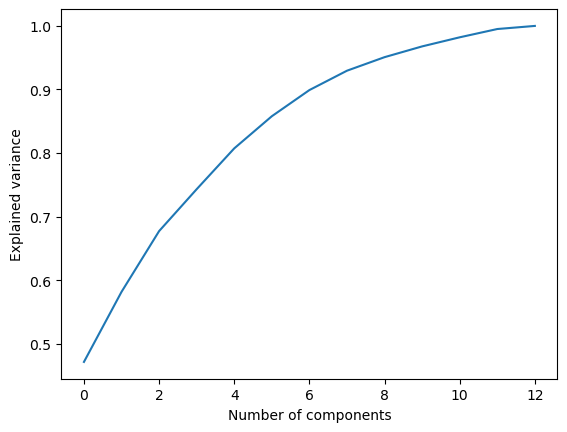

```python
# Plot pca variance
plt.plot(np.cumsum(pca.explained_variance_ratio_))
plt.xlabel('Number of components')
plt.ylabel('Explained variance')
```

```python
# View heatmap
#f, ax = plt.subplots(figsize=(20,20))
#sns.heatmap(df_std_pca.corr(), center=0, linewidth=0.8, cmap='twilight', annot=True)
```

## Part 4 - Building the Model - 20%

● Fit the model using (k) Principal Components. (k) should be determined from looking at the sorted array of principal components.

```python
df_std_pca
```

|  | PCA1 | PCA2 | PCA3 | PCA4 | PCA5 | PCA6 | PCA7 | PCA8 | PCA9 | PCA10 | PCA11 | PCA12 | PCA13 | medv |
| --- | --- | --- | --- | --- | --- | --- | --- | --- | --- | --- | --- | --- | --- | --- |
| 0 | -2.098297 | 0.773113 | 0.342943 | -0.891774 | 0.423070 | -0.315338 | 0.318641 | 0.295832 | -0.424937 | 0.640206 | -0.033000 | 0.019440 | 0.365975 | 24.0 |
| 1 | -1.457252 | 0.591985 | -0.695199 | -0.487459 | -0.195876 | 0.264223 | 0.553861 | -0.223670 | -0.166962 | 0.084236 | -0.640810 | -0.125797 | -0.070719 | 21.6 |
| 2 | -2.074598 | 0.599639 | 0.167122 | -0.739204 | -0.934534 | 0.448095 | 0.484560 | 0.105166 | 0.069775 | -0.180380 | -0.487557 | 0.133327 | -0.014022 | 34.7 |
| 3 | -2.611504 | -0.006871 | -0.100284 | -0.343721 | -1.104956 | 0.664649 | 0.622641 | 0.255941 | -0.342246 | 0.045901 | -0.360209 | 0.508678 | 0.007847 | 33.4 |
| 4 | -2.458185 | 0.097712 | -0.075348 | -0.427907 | -1.065924 | 0.617047 | 0.705086 | -0.134524 | -0.417668 | -0.140880 | -0.395150 | 0.497732 | 0.014274 | 36.2 |
| ... | ... | ... | ... | ... | ... | ... | ... | ... | ... | ... | ... | ... | ... | ... |
| 501 | -0.314968 | 0.724285 | -0.860896 | -0.434740 | -1.121040 | 0.508064 | 0.199056 | -0.249896 | 0.877036 | 0.183086 | 0.493590 | 0.450386 | 0.078978 | 22.4 |
| 502 | -0.110513 | 0.759308 | -1.255979 | -0.309376 | -0.891542 | 0.408208 | 0.191779 | -0.146502 | 0.853628 | 0.631847 | 0.375688 | 0.252082 | 0.037162 | 20.6 |
| 503 | -0.312360 | 1.155246 | -0.408598 | -0.786304 | -1.595185 | 0.467947 | 0.294119 | -0.638660 | 0.981032 | 0.589670 | 0.115656 | 0.281964 | 0.062474 | 23.9 |
| 504 | -0.270519 | 1.041362 | -0.585454 | -0.678134 | -1.416024 | 0.482259 | 0.271597 | -0.579344 | 0.936755 | 0.594610 | 0.087012 | 0.301701 | 0.054370 | 22.0 |
| 505 | -0.125803 | 0.761978 | -1.294882 | -0.288329 | -0.890969 | 0.401474 | 0.175310 | -0.133382 | 0.854689 | 0.823404 | 0.184321 | 0.232733 | 0.019709 | 11.9 |

506 rows × 14 columns

```python
print("Variance Array: \n", pca.explained_variance_ratio_,"\n")
print ("Cumulative Variance Percentage Array: \n", np.cumsum(pca.explained_variance_ratio_ * 100), "\n")
print("Total Variance:", round(sum(list(pca.explained_variance_ratio_))*100, 3))
```

```
Variance Array:
 [0.47129606 0.11025193 0.0955859  0.06596732 0.06421661 0.05056978
 0.04118124 0.03046902 0.02130333 0.01694137 0.0143088  0.01302331
 0.00488533]

Cumulative Variance Percentage Array:
 [ 47.12960636  58.1547996   67.7133894   74.310121    80.73178205
  85.78876032  89.90688406  92.95378648  95.08411979  96.7782569
  98.20913665  99.51146723 100.        ]

Total Variance: 100.0
```

```python
# Components with 85.78876032% variance retained
final_pca = df_std_pca.drop(columns = ['PCA7','PCA8','PCA9','PCA10','PCA11','PCA12','PCA13'])
final_pca
```

|  | PCA1 | PCA2 | PCA3 | PCA4 | PCA5 | PCA6 | medv |
| --- | --- | --- | --- | --- | --- | --- | --- |
| 0 | -2.098297 | 0.773113 | 0.342943 | -0.891774 | 0.423070 | -0.315338 | 24.0 |
| 1 | -1.457252 | 0.591985 | -0.695199 | -0.487459 | -0.195876 | 0.264223 | 21.6 |
| 2 | -2.074598 | 0.599639 | 0.167122 | -0.739204 | -0.934534 | 0.448095 | 34.7 |
| 3 | -2.611504 | -0.006871 | -0.100284 | -0.343721 | -1.104956 | 0.664649 | 33.4 |
| 4 | -2.458185 | 0.097712 | -0.075348 | -0.427907 | -1.065924 | 0.617047 | 36.2 |
| ... | ... | ... | ... | ... | ... | ... | ... |
| 501 | -0.314968 | 0.724285 | -0.860896 | -0.434740 | -1.121040 | 0.508064 | 22.4 |
| 502 | -0.110513 | 0.759308 | -1.255979 | -0.309376 | -0.891542 | 0.408208 | 20.6 |
| 503 | -0.312360 | 1.155246 | -0.408598 | -0.786304 | -1.595185 | 0.467947 | 23.9 |
| 504 | -0.270519 | 1.041362 | -0.585454 | -0.678134 | -1.416024 | 0.482259 | 22.0 |
| 505 | -0.125803 | 0.761978 | -1.294882 | -0.288329 | -0.890969 | 0.401474 | 11.9 |

506 rows × 7 columns

```python
# Create 6 principal components for around 85% variance

pca = PCA(n_components = 6)

pcaComponents = ['PCA1','PCA2','PCA3','PCA4','PCA5','PCA6']

X = final_pca[pcaComponents]
y = final_pca.medv
```

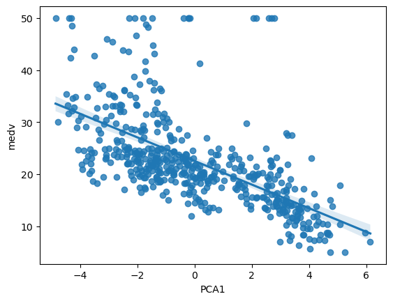

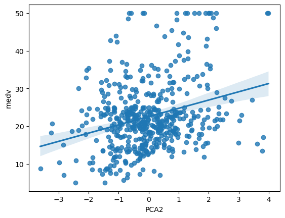

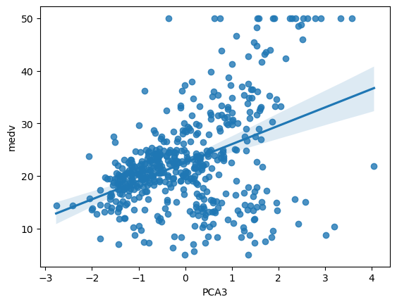

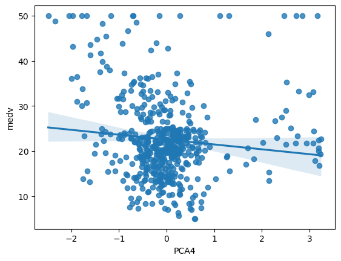

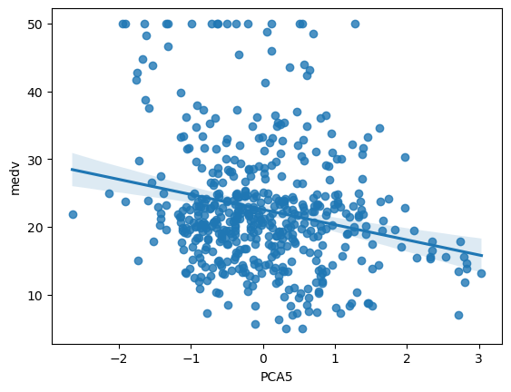

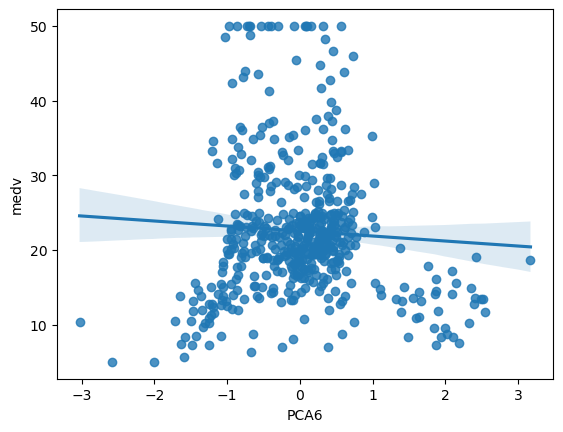

```python
# Plot the relationship highly correlated features

for var in ['PCA1','PCA2','PCA3','PCA4','PCA5','PCA6']:
    sns.regplot(x=final_pca[var], y=final_pca['medv'], data = final_pca)
    plt.show()
```

```python
# Split df into train and test sets 80% training and 20% test
X_train, X_test, y_train, y_test = train_test_split(X, y, test_size=0.2, random_state=42)
```

```python
# Create linear regression object
linearRegModel2 = LinearRegression()

# Train linear regression model 2
linearRegModel2 = linearRegModel2.fit(X_train,y_train)

# Predict the response for test dataset
y_pred = linearRegModel2.predict(X_test)
```

● Perform 10 Fold Cross Validation

```python
# Establish 10 fold cross-validation
folds = KFold(n_splits = 10, shuffle = True, random_state = 42)

# Obtain cross validation score w/ neg_root_mean_squared_error
scores = cross_val_score(linearRegModel2, X_train, y_train, scoring='neg_root_mean_squared_error', cv=folds)
scores
```

```
array([-3.44520643, -6.37579554, -5.13816243, -4.69922554, -6.97089573,
       -5.94231825, -4.28836098, -5.41237841, -3.31529564, -3.68745871])
```

● Report mean of RMSE

```python
# Calculate mean of RMSE for PCA model
rmseMean2 = np.mean(np.absolute(scores))
rmseMean2
```

```
4.927509767350022
```

● Report SD of RMSE

```python
# Calculate standard deviation of RMSE for PCA model
rmseStd2 = np.std(np.absolute(scores))
rmseStd2
```

```
1.1990444265149278
```

## Part 5 - Analysis - 20%

Which model had the best accuracy? Using PCA or handpicked features? Provide chart of RMSE from both models

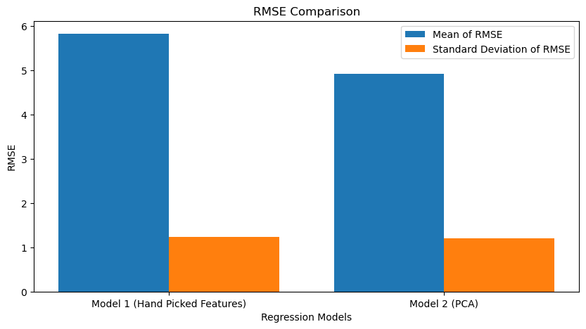

```python
# Pairs of bars
N = 2

# Data on X-axis
rmseMean = rmseMean1,rmseMean2
# Specify the values of orange bars (height)
rmseSTD = rmseStd1,rmseStd2

# Position of bars on x-axis
ind = np.arange(N)

# Figure size
plt.figure(figsize=(10,5))

# Width of a bar
width = 0.4

# Plotting data
plt.bar(ind, rmseMean , width, label='Mean of RMSE')
plt.bar(ind + width, rmseSTD, width, label='Standard Deviation of RMSE')

plt.title('RMSE Comparison')
plt.xlabel('Regression Models')
plt.ylabel('RMSE')

plt.xticks(ind + width / 2, ('Model 1 (Hand Picked Features)', 'Model 2 (PCA)'))

plt.legend(loc='best')
plt.show()
```

Based on the chart above, we can see that PCA (Model 2) has a better RMSE than handpicked features (Model 1). The average RMSE from PCA is 4.927509767350022, which is less than our initial model with handpicked features which has an average RMSE of 5.825224945569638. Usually, the lower the value of RMSE, the better the model's accuracy. Therefore, PCA has a better accuracy. This is also most likely because PCA identifies specific principal components which can be used to understand the variance. Once doing so, we can apply PCA to our model while taking into account the specific threshold we are looking for.

Also, the standard deviation of RMSE in the PCA model is 1.1990444265149278, less than the hand picked model which has a standard deviation of RMSE of 1.2385310312184938. Therefore, we can see that the RMSE (although slight) is closer to the mean in the PCA model as opposed to the handpicked model.